# Modeling Inflation and the Consumer Price Index

Jules Bertholet's CMSC320 final project

## Introduction

Inflation has been in the news recently; US rates of inflation are currently quite high due to effects of the COVID-19 pandemic, policies pursued by governments in response to said pandemic, Russia's invasion of Ukraine, and other factors. Excessive inflation devalues people's savings and destroys their investments, worsening poverty and economic inequality. By better understanding inflation, we can hopefully learn to bring it under control.

The federal government's Bureau of Labor Statistics (BLS) continuously monitors the price of goods and services and puts out a measure called the [Consumer Price Index](https://www.bls.gov/cpi/). The CPI represents the cost of a "basket of goods" representative of what the average person needs every day. In addition to the computed CPI, the BLS also publishes data about the prices of the individual goods and services that go into the "basket".

Our objective is to use this raw data to determine what factors most affect the final CPI figure, and then develop a model that can predict the CPI in arbitrary years given information about those factors.

## Data collection and processing

Instead of getting our data directly from BLS, we'll use a repackaged version of the data made available by Microsoft as part of their "Azure Open Datasets" program. More details can be found [in Microsoft's documentation](https://docs.microsoft.com/azure/open-datasets/dataset-us-consumer-price-index). Microsoft doesn't offer a raw file download of their dataset in a standard format, so I've made a CSV ([zstd](https://facebook.github.io/zstd/)-compressed) available here.

The dataset has already been cleaned up nicely by Microsoft, so we don't need to do much processing. However, one downside of using the Microsoft data instead of getting it directly from BLS is that Microsoft's dataset only goes up to 2019 (pre-COVID). But this may actually be a blessing in disguise. If we can develop our model of the CPI using pre-COVID data, but then evaluate the model on post-COVID data, we'll be able to see how well our results generalize beyond the time period used to develop the model.

First, we load the dataset into Pandas from the CSV:

```python
import numpy as np
import pandas as pd

# Unfortunately, Microsoft's library to load Azure datasets into Pandas
# requires some dependencies that are difficult to obtain outside Windows.
# Because I don't want to be tied to Windows for the entire development process,
# I created a CSV of the data using a Windows VM, and then copied the CSV file over to my
# main development environment (the one that runs this notebook).
# Additionally, as the CSV is many megabytes in size, I compressed it using `zstd`,
# so it must be decompressed when loaded into Pandas.

df = pd.read_csv(
    "cpi.csv.zst",
    compression="zstd",
    dtype={
        "area_code": "category",
        "item_code": "category",
        "series_id": str,
        "year": np.int32,
        "period": "category",
        "value": np.float32,
        "footnote_codes": object,
        "seasonal": "category",
        "periodicity_code": "category",
        "series_title": str,
        "item_name": str,
        "area_name": str,
    },
)

# These columns are useless, get rid of them
df.drop(["footnote_codes", "periodicity_code"], axis=1, inplace=True)

# We care only about the "All urban consumers" data.
# Get rid of everything else
df = df[[id[0:2] == "CU" for id in df.series_id]].reindex(copy=False)

# Combine "year" and "period" into "time_span" column that uses the
#  native Pandas time-period type
# "period" code reference: https://download.bls.gov/pub/time.series/cu/cu.period


def combine_year_period(y: np.int32, period):
    if period == "M13" or period == "S03":
        return pd.Period(year=y, freq="Y")
    elif period == "S01":
        return pd.Period(year=y, freq="6M")
    elif period == "S02":
        return pd.Period(year=y, month=7, freq="6M")
    else:
        return pd.Period(year=y, month=int(period[1:3]), freq="M")


df["time_period"] = [combine_year_period(r[0], r[1]) for r in zip(df.year, df.period)]


df
```

|  | area_code | item_code | series_id | year | period | value | seasonal | series_title | item_name | area_name | time_period |
| --- | --- | --- | --- | --- | --- | --- | --- | --- | --- | --- | --- |
| 0 | S49E | SEHF01 | CUURS49ESEHF01 | 2017 | M12 | 279.973999 | U | Electricity in San Diego-Carlsbad, CA, all urb... | Electricity | San Diego-Carlsbad, CA | 2017-12 |
| 1 | S49E | SEHF01 | CUURS49ESEHF01 | 2018 | M01 | 284.455994 | U | Electricity in San Diego-Carlsbad, CA, all urb... | Electricity | San Diego-Carlsbad, CA | 2018-01 |
| 2 | S49E | SEHF01 | CUURS49ESEHF01 | 2018 | M02 | 284.455994 | U | Electricity in San Diego-Carlsbad, CA, all urb... | Electricity | San Diego-Carlsbad, CA | 2018-02 |
| 3 | S49E | SEHF01 | CUURS49ESEHF01 | 2018 | M03 | 284.455994 | U | Electricity in San Diego-Carlsbad, CA, all urb... | Electricity | San Diego-Carlsbad, CA | 2018-03 |
| 4 | S49E | SEHF01 | CUURS49ESEHF01 | 2018 | M04 | 283.085999 | U | Electricity in San Diego-Carlsbad, CA, all urb... | Electricity | San Diego-Carlsbad, CA | 2018-04 |
| ... | ... | ... | ... | ... | ... | ... | ... | ... | ... | ... | ... |
| 1762820 | 0480 | SAT | CUUR0480SAT | 2019 | M07 | 106.459000 | U | Transportation in Mountain, all urban consumer... | Transportation | Mountain | 2019-07 |
| 1762842 | 0480 | SAT | CUUS0480SAT | 2018 | S01 | 103.488998 | U | Transportation in Mountain, all urban consumer... | Transportation | Mountain | 2018-01 |
| 1762843 | 0480 | SAT | CUUS0480SAT | 2018 | S02 | 106.093002 | U | Transportation in Mountain, all urban consumer... | Transportation | Mountain | 2018-07 |
| 1762844 | 0480 | SAT | CUUS0480SAT | 2018 | S03 | 104.791000 | U | Transportation in Mountain, all urban consumer... | Transportation | Mountain | 2018 |
| 1762845 | 0480 | SAT | CUUS0480SAT | 2019 | S01 | 104.483002 | U | Transportation in Mountain, all urban consumer... | Transportation | Mountain | 2019-01 |

810976 rows × 11 columns

Our resulting dataframe contains one row for each measurement of the price of an item or collection of items, for a particular time period and geographic location, measured in a particular way.

The columns, in order:

- `area_code` (Pandas categorical datatype) is an alphanumeric code indicating the geographic location the price estimate is for. The codes are defined [here](https://download.bls.gov/pub/time.series/cu/cu.area).
- `item_code` (Pandas categorical datatype) is an alphanumeric code indicating the item type (category of goods or services) that the price estimate is for. The codes are defined [here](https://download.bls.gov/pub/time.series/cu/cu.item).
- `series_id` (string) contains an ID representing what series the item is for. A series represents the same measurement repeated over time.
- `year` (integer) is the calendar year of the observation.
- `period` (Pandas categorical datatype) is an alphanumeric code indicating the portion of the year that the measurment covers. The codes are defined [here](https://download.bls.gov/pub/time.series/cu/cu.period).
- `value` (float) is the measured monetary value of the goods or services.
- `seasonal` (Pandas categorical datatype) is `S` when the observation is seasonally adjusted and `U` otherwise.
- `item_name` (string) is a human-friendly name for then item referred to by `item_code`.
- `item_name` (string) is a human-friendly name for then item referred to by `item_code`.
- `time_period` (Pandas time period) represents the exact span of time covered by the observation.

## Exploratory analysis

The CPI data is parametrized by many different variables, including year, season, geographic location, and the specific good or service. We need to develop a sense of how each of these variables interact to affect consumer prices, and determine which interactions seem most significant.

### Change over time

In our first series of plots, we'll focus on how the prices of different categories of goods and services have changed over time, nationally and within geographical regions.

We'll start with a series of scatter plots. Each scatter plot corresponds to either the overall CPI, or to a specific item type. Each plot has five data series: one per US geographical region (Northeast, Midwest, South, and West), and one for overall US figures. For each series, we plot the average value of the item in the geographical region for each year.

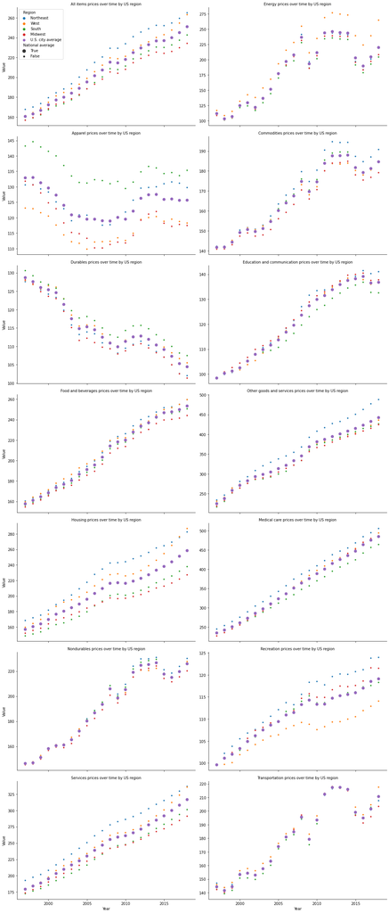

```python
import matplotlib.pyplot as plt
import seaborn as sns

# List of all item categories to plot
items = [
    "All items",
    "Energy",
    "Apparel",
    "Commodities",
    "Durables",
    "Education and communication",
    "Food and beverages",
    "Other goods and services",
    "Housing",
    "Medical care",
    "Nondurables",
    "Recreation",
    "Services",
    "Transportation",
]

# Filter the dataframe to get only the data points we want
df_all_items_yearly = df[
    [
        # Average price for all items (https://download.bls.gov/pub/time.series/cu/cu.item)
        r[0] in items
        # No seasonal adujustment (https://download.bls.gov/pub/time.series/cu/cu.seasonal)
        and r[1] == "U"
        # Annual (https://download.bls.gov/pub/time.series/cu/cu.period)
        and r[2] == "S03"
        # 4 main geographical areas (https://download.bls.gov/pub/time.series/cu/cu.area), and whole country
        and r[3] in ["0000", "0100", "0200", "0300", "0400"]
        for r in zip(df.item_name, df.seasonal, df.period, df.area_code)
    ]
].reindex()

# Make scatterplots of the CPI per year and region for each item

df_all_items_yearly = df_all_items_yearly[
    ["item_code", "item_name", "area_code", "area_name", "year", "value"]
]
df_all_items_yearly.rename(
    columns={
        "item_name": "Item",
        "area_name": "Region",
        "year": "Year",
        "value": "Value",
    },
    inplace=True,
)
df_all_items_yearly["National average"] = df_all_items_yearly.area_code == "0000"

gd: sns.FacetGrid = sns.relplot(
    x="Year",
    y="Value",
    hue="Region",
    size="National average",
    size_order=[True, False],
    col="Item",
    col_order=items,
    data=df_all_items_yearly,
    aspect=1.5,
    col_wrap=2,
    facet_kws={"sharex": True, "sharey": False, "legend_out": False},
)

_ = gd.set_titles("{col_name} prices over time by US region")
```

There is consistent upward trend to overall all-items prices, which indicates consistent year-over-year inflation. In addition, there are significant differences between the geographical regions: prices are generally highest in the Northeast and usually lowest in the Midwest. However, it appears that since 2015, prices in the West have been inching up closer and closer to prices in the Northeast. A few item categories (commodities, energy, transportation) appear more variable than the others, and two (apparel and durables) buck the inflationary trend, with a decrease in price from 1997 to today.

Unfortunately, the strong overall upward trend makes the relative differences between the regions difficult to tease out. Let's make some plots! These will be equivalent to the previous ones, but with the CPI for each region normalized through division by the nationwide figure for that year.

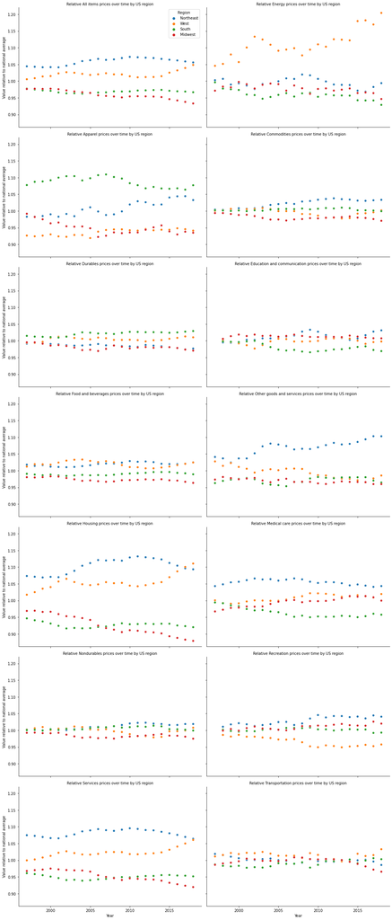

```python
# Make dataframe with only regional yearly data
df_all_items_yearly_regional = df_all_items_yearly[
    df_all_items_yearly.area_code != "0000"
].copy()

# Make dataframe with only national yearly data
df_all_items_yearly_national = df_all_items_yearly[
    df_all_items_yearly.area_code == "0000"
].copy()

# Add a column to the regional dataframe for relative price
nat_idx = df_all_items_yearly_national.set_index(["Year", "item_code"], inplace=False)

df_all_items_yearly_regional["Value relative to national average"] = [
    v / nat_idx.loc[(y, ic), "Value"]
    for (y, ic, v) in zip(
        df_all_items_yearly_regional["Year"],
        df_all_items_yearly_regional.item_code,
        df_all_items_yearly_regional["Value"],
    )
]

# Plot relative prices by region
gd: sns.FacetGrid = sns.relplot(
    x="Year",
    y="Value relative to national average",
    hue="Region",
    col="Item",
    col_order=items,
    data=df_all_items_yearly_regional,
    aspect=1.5,
    col_wrap=2,
    facet_kws={"sharex": True, "sharey": True, "legend_out": False},
)

_ = gd.set_titles("Relative {col_name} prices over time by US region")
```

Overall, the Northeast and West generally have higher prices compared to the South and Midwest. Housing, and services follow this overall trend the most cleanly. In contrast, energy is much more expensive in the West than anywhere else, and the gap appears to be widening. And apparel is most expensive in the South.

### Correlation between different items

We now have an idea of how time affects the prices of different kinds of items. Next, we'll explore how the prices of items are related to one another. But there's a catch: we need to disambiguate the association directly between prices from their common association with the year. If you already know the year, how much additional predictive power does knowing the price of one item give you to predict the price of other items? To find out, we'll perform a linear regression of the value of each item category with respect to year. Next, for each potential pair of item categories, we'll do a linear regression of the residuals of the previous regression. This way, we can determine whether the prices of two categories of goods are related in a way that's independent of the overall inflationary trend.

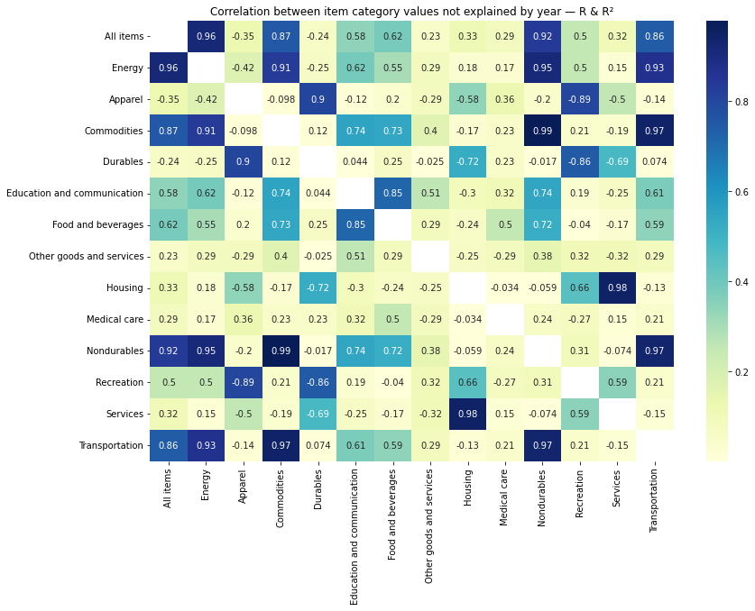

```python
# Bigger graphs
plt.rcParams["figure.figsize"] = (13, 9)  # (w, h)

# Item category -> series of values
items_vals = {}

for item in items:
    item_df = df_all_items_yearly_national[
        df_all_items_yearly_national["Item"] == item
    ].set_index("Year")
    item_df.sort_index(axis=1)
    items_vals[item] = item_df["Value"]

# Will contain pairwise R
r_df = pd.DataFrame(columns=items, index=items, dtype=np.float64)
# Will contain pairwise R-squared
rsq_df = pd.DataFrame(columns=items, index=items, dtype=np.float64)
# Will contain pairwise F-test p-values
f_df = pd.DataFrame(columns=items, index=items, dtype=np.float64)
# Will contain pairwise F-test p-values (base 10 log)
logf_df = pd.DataFrame(columns=items, index=items, dtype=np.float64)
# Will contain "True" on the main diagonal, to mask those cells out (self-correlation is uninteresting)
mask = pd.DataFrame(columns=items, index=items, dtype=bool)

# List of years, to serve as predictor
years = list(
    df_all_items_yearly_national[df_all_items_yearly_national["Item"] == items[0]]
    .set_index("Year")
    .sort_index(axis=1)
    .index
)

from sklearn.linear_model import LinearRegression
from sklearn.feature_selection import f_regression, r_regression

# Run loop for cartesian product { item categories } x { item categories }
for item1 in items:
    for item2 in items:
        multi1_transposed = np.transpose([items_vals[item1], years])
        years_transposed = np.transpose([years])

        # Linear regression year -> item1
        item1_years_regress = LinearRegression().fit(
            years_transposed, items_vals[item1]
        )
        item1_years_residuals = [
            v - item1_years_regress.predict([[y]])[0]
            for (y, v) in zip(years, items_vals[item1])
        ]

        # Linear regression year -> item2
        item2_years_regress = LinearRegression().fit(
            years_transposed, items_vals[item2]
        )
        item2_years_residuals = [
            v - item2_years_regress.predict([[y]])[0]
            for (y, v) in zip(years, items_vals[item2])
        ]

        # Linear regression (year -> item1 residuals) -> (year -> item2 residuals)
        r_reg = r_regression(
            np.transpose([item1_years_residuals]), item2_years_residuals
        )
        r_df.loc[item2, item1] = r_reg[0]
        rsq_df.loc[item2, item1] = r_df.loc[item2, item1] ** 2

        # Same as above, but F-test
        f_reg = f_regression(
            np.transpose([item1_years_residuals]),
            np.transpose(item2_years_residuals),
            force_finite=False,
        )
        # Take log of p-value for nicer scale
        f_df.loc[item2, item1] = f_reg[1][0] if item2 != item1 else 0
        logf_df.loc[item2, item1] = (
            np.log10(f_df.loc[item2, item1]) if item2 != item1 else -np.inf
        )

        mask.loc[item2, item1] = item2 == item1

# Heatmap of R^2 values
heat = sns.heatmap(rsq_df, cmap="YlGnBu", mask=mask, annot=r_df)
_ = heat.set_title(
    "Correlation between item category values not explained by year — R & R²"
)
```

Above is a heatmap of the $R$ and $R^2$ values for all the pairwise regressions. The number in each box is the $R$-value, and the hue corresponds to $R^2$. The empty white spaces down the main diagonal represent the correlation of each item category price with itself; this is always 1 and completely uninteresting. Dark blue signals a strong correlation, light yellow a weak one. Again, these are partial correlations; we are measuring the portion of the correlation between item values that isn't explained by year.

It seems that some combinations of items are much more strongly correlated in price than others. Energy, commodities, nondurables, and transportation seem to be the most strongly correlated with other item categories; this suggests that these item categories are especially significant or fundamental in some way. This result seems reasonable:

- Energy is the ability to do work, it it necessary for any economic activity
- Every product starts with raw materials, many of which are commodities
- Nondurables must by definition be replaced often, so changes in their price are significant
- Most products need to be shipped to the customer, and most workers commute to workin some fashion, so transportation costs affect nearly every economic activity

There's also a strong link between housing and services costs.

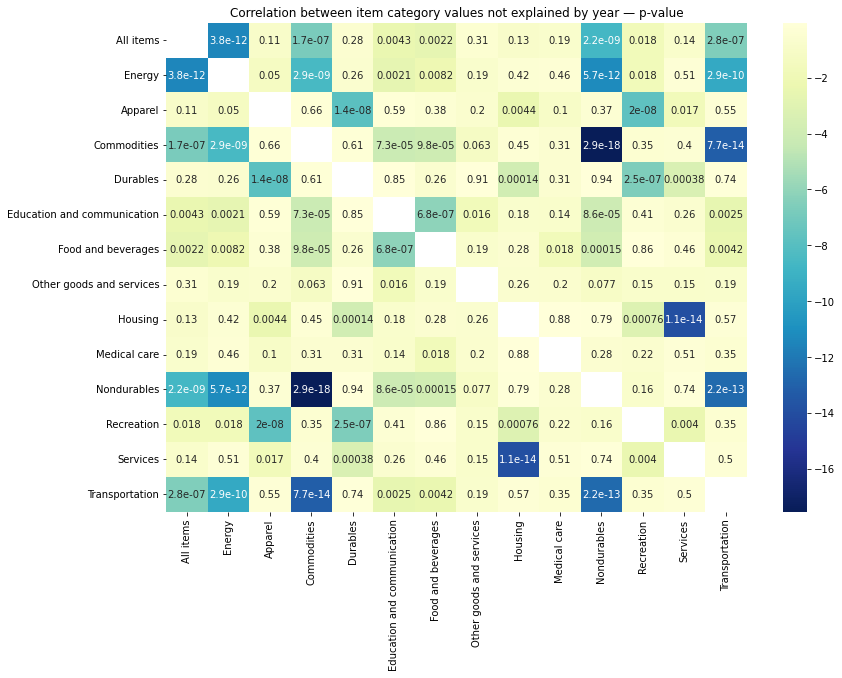

```python
# Heatmap of F-test p-values. Label with the p-value but color according to log scale
heat = sns.heatmap(logf_df, cmap="YlGnBu_r", mask=mask, annot=f_df)
_ = heat.set_title(
    "Correlation between item category values not explained by year — p-value"
)
```

Above is a heatmap of the statistical significance $p$-values (F-test) for correlations in the last plot. Dark blue signifies a more statistically significant result (less likely to arise by chance). We print the raw $p$-value number in the boxes, but the boxes are colored according to a log scale. Note that these $p$-values are *not* adjusted for multiple comparisons, so we will need to tighten our standards for what constitutes a "significant" result by a few orders of magnitude to compensate.

The most statistically significant results correspond to the ones with high $R^2$ values above: energy, commodities, nondurables, and transportation, as well as a strong link between housing and services.

## Making the model

Through our explorations, we've developed a good impression of what the most important factors affecting the CPI are. The list:

- Year
- Region of the U.S.
- Price of energy, commodities, nondurables, and transportation

Armed with this knowledge, we'll create a linear model that attempts to predict the CPI in an arbitrary year and US region, based on these factors.

Our linear model will have one feature for the year, one feature each for the price of energy, commodities, nondurables, and transportation, and an interaction feature for region of the country.

We'll start by preparing the interaction feature and the other features we need, in a common Pandas dataframe.

```python
df_all_items_yearly_avg = df_all_items_yearly[
    df_all_items_yearly["Item"] == "All items"
].set_index(["area_code", "Year"], drop=False)

# Map each region to a coefficent for the interaction feature.
def coefficient_from_region(region_code):
    if region_code == "0000":
        return 0  # US Average - no per-region modifier
    elif region_code == "0100":
        return 2  # Northeast - highest priced region
    elif region_code == "0400":
        return 1  # West - second highest priced region
    elif region_code == "0300":
        return -1  # South - second lowest priced region
    elif region_code == "0200":
        return -2  # Midwest - lowest priced region
    else:
        raise Exception("ohnoes")


# Add a column for interaction coefficient to the dataframe
df_all_items_yearly_avg["Region interaction"] = [
    coefficient_from_region(r) for r in df_all_items_yearly_avg.area_code
]

# Add columns for price of each item category out of the 4 we chose
df_all_items_yearly_regyear_idx = df_all_items_yearly.set_index(
    ["area_code", "Year", "Item"], inplace=False
)

for item in ["Energy", "Commodities", "Nondurables", "Transportation"]:
    df_all_items_yearly_avg[item + " Value"] = 0
    df_all_items_yearly_avg[item + " Value"].astype(np.float32, copy=False)

    for (r, y) in zip(
        df_all_items_yearly_avg.area_code, df_all_items_yearly_avg["Year"]
    ):
        df_all_items_yearly_avg.loc[
            (r, y), item + " Value"
        ] = df_all_items_yearly_regyear_idx.loc[(r, y, item), "Value"]
```

Now that all the model features have been set up, we create the linear model:

```python
# Model features
model_x = np.transpose(
    [
        df_all_items_yearly_avg["Year"],
        df_all_items_yearly_avg["Region interaction"],
        df_all_items_yearly_avg["Energy Value"],
        df_all_items_yearly_avg["Commodities Value"],
        df_all_items_yearly_avg["Nondurables Value"],
        df_all_items_yearly_avg["Transportation Value"],
    ]
)

# Fit the model
model = LinearRegression().fit(
    model_x,
    # Trying to predict overall CPI
    df_all_items_yearly_avg["Value"],
)

# Print model coefficients
model.coef_
```

```
array([ 4.93904892,  3.24455452,  0.20726944,  2.15555782, -1.35828842,
       -0.32670968])
```

Strangely, it appears that the resulting model weights the price of nondurables and transportation *negatively* when predicting the final price. I honestly have no idea why this is, as both of these values are positively correlated with the overall price even when the influence of year is factored out (see heatmaps above).

```python
# Calculate and print model F-statistics
fstats = f_regression(
    model_x,
    df_all_items_yearly_avg["Value"],
)

fstats
```

```
(array([1196.7420325 ,    7.44666648,  302.43968697, 1081.28459007,
        1121.98118948,  556.4294158 ]),
 array([2.94564810e-60, 7.42118748e-03, 4.35058198e-33, 4.40506531e-58,
        7.14768718e-59, 2.06359307e-44]))
```

Finally, we test our model on newer data to see how well it holds up. I've compiled the 2020 and 2021 data [from BLS](https://download.bls.gov/pub/time.series/cu/) manually into a set of test cases of the model. We'll use `scikit-learn` to calculate $R^2$ from this test data.

```python
# Test data manually from https://download.bls.gov/pub/time.series/cu/
# Score is R^2

# These are the inputs to the model. Each row is one test case
test_X = [
    [2020, +0, 196.949, 184.799, 224.974, 201.334],
    [2021, +0, 238.325, 199.227, 239.982, 230.657],
    [2020, +2, 194.545, 190.108, 228.918, 198.336],
    [2021, +2, 231.392, 203.876, 242.519, 223.794],
    [2020, +1, 247.815, 188.983, 232.450, 210.142],
    [2021, +1, 298.486, 203.297, 248.139, 240.041],
    [2020, -1, 180.438, 183.047, 222.304, 200.623],
    [2021, -1, 218.120, 197.772, 237.538, 231.502],
    [2020, -2, 182.916, 178.231, 216.847, 194.371],
    [2021, -2, 226.720, 192.835, 231.900, 223.429],
]

# These are our taret CPI predictions
test_y = [
    258.811,
    270.970,
    272.908,
    283.557,
    275.057,
    287.49,
    248.639,
    261.259,
    240.040,
    252.242,
]

model.score(test_X, test_y)
```

```
0.8695864476708095
```

$R^2 \approx 0.87$; this high value means that our model was very accurate.

Finally, we need to evaluate how much better our model is compared to a simpler one that only takes into account year and geography. Was all of this truly worth the effort? To answer this question, we'll use the partial $R^2$ formula:

$$ R^2_{partial} = \frac{SS_{simple} - SS_{full}}{SS_{simple}} $$

where $SS_{model}$ is the sum of the squares of the residuals for a particular model (learn more [on Wikipedia](https://en.wikipedia.org/wiki/Coefficient_of_determination#Coefficient_of_partial_determination)). We'll use the residuals of the test dataset.

```python
# Only take into account year and geography
simple_model_x = np.transpose(
    [
        df_all_items_yearly_avg["Year"],
        df_all_items_yearly_avg["Region interaction"],
    ]
)

# Fit the simple model
simple_model = LinearRegression().fit(
    simple_model_x,
    # Trying to predict overall CPI
    df_all_items_yearly_avg["Value"],
)

# Calculate sum squared residuals for simple model
ss_simple = sum(
    [
        (
            simple_model.coef_[0] * X[0]
            + simple_model.coef_[1] * X[1]
            + simple_model.intercept_
            - y
        )
        ** 2
        for (X, y) in zip(test_X, test_y)
    ]
)

# Calculate sum squared residuals for full model
ss_full = sum(
    [
        (
            model.coef_[0] * X[0]
            + model.coef_[1] * X[1]
            + model.coef_[2] * X[2]
            + model.coef_[3] * X[3]
            + model.coef_[4] * X[4]
            + model.coef_[5] * X[5]
            + model.intercept_
            - y
        )
        ** 2
        for (X, y) in zip(test_X, test_y)
    ]
)

# Plug into formula
(ss_simple - ss_full) / ss_simple
```

```
0.5195006309596102
```

We get a partial $R^2 \approx 0.52$. This is a reasonably high result; it indicates that our 6-feature model of CPI is more predictive than a simpler 2-feature model would be by a significant amount. The extra features are "pulling their weight".

## Conclusion

Our analysis of the BLS's price data revealed multiple interesting facts about the factors that drive consumer prices:

- The US has been experiencing steady inflation for the past few decades
- Prices vary significantly and consistently between geographical regions
- Prices in four categories have an especially strong relationship to prices everywhere else: energy, commodities, nondurables, and transportation. Policymakers who want to bring prices down may want to prioritize these categories.

Using this information, we were able to construct a model that accurately predicted the Consumer Price Index for 2020 and 2021, even though COVID-19 significantly affected the situation during those years. We also demonstrated that our model was more accurate than a simpler one would have been.

However, we've only scratched the surface of all the potential analyses we could perform. We've only considered full-year data so far; in the future we could extend our analysis to the monthly and seasonal figures. We don't have an explanation for the negative weighting of nondurables and transportation in our model; we could search for one. We could use non-linear modelling techniques to try to get better predictions. We could bring in dta from outside sources; maybe inflation is linked to happiness, or weather, or trade, or any of a million other factors. There is easily a lifetime's worth of additional analysis that could be performed on this topic. But we'll end our tutorial here for now.